# Prozessierung von LiDAR-Daten mit dem lidR Paket

Florian Franz & Jens Wiesehahn

2023-06-07

### Die Dateiformate zur Speicherung von LiDAR-Daten: .las/.laz

**LAS (Lidar Application Schema)**

- speziell für die Speicherung von LiDAR-Daten entwickelt
- Standard Format
- können sowohl rohe als auch verarbeitete LiDAR-Daten enthalten
- Informationen zu Punktkoordinaten, Klassifizierungen, Intensitäten, …

**LAZ (LASzip Compressed Lidar)**

- komprimierte Version des LAS-Formats
- verringerte Dateigröße –> effektiverer Speicherung und Verarbeitung
- sonst gleiche Struktur wie LAS-Dateien

### Das R Paket *lidR*

*“lidR ist ein R-Paket zur Manipulation und Visualisierung von Airborne Laser Scanning (ALS) Daten mit dem Schwerpunkt auf forstwirtschaftliche Anwendungen”* (Roussel et al. 2022).

- entwickelt im Rahmen des [AWARE](https://awareproject.ca/) Projekts an der University of British Columbia (2015-2018)
- weiterentwickelt durch finanzielle Unterstützung des [Ministère des Forêts, de la Faune et des Parcs of Québec](https://www.quebec.ca/gouvernement/ministere/forets-faune-parcs) an der [Laval University](https://www.ulaval.ca/en) (2018-2021)
- Hauptentwickler: Jean-Romain Roussel
- Publikation: [lidR: An R package for analysis of Airborne Laser Scanning (ALS) data](https://www.sciencedirect.com/science/article/pii/S0034425720304314)
- open source: [CRAN](https://cran.r-project.org/web/packages/lidR/), [GitHub](https://github.com/r-lidar/lidR)

### Import einer LAZ-Datei

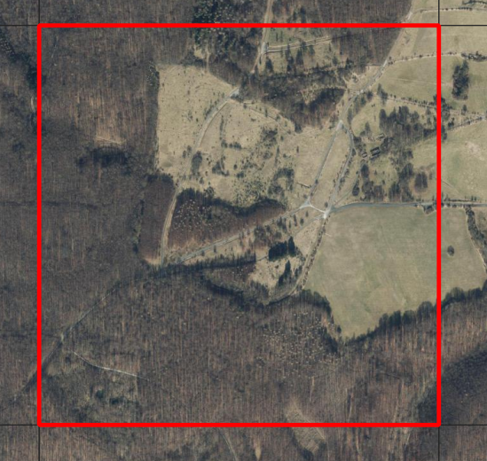

```r
las_files <- list.files(input_dir,
                        pattern = glob2rx("*.laz"),
                        full.names = TRUE)

las <- readLAS(las_files)

print(las)
```

```
## class        : LAS (v1.2 format 1)
## memory       : 2 Gb
## extent       : 569000, 570000, 5708000, 5709000 (xmin, xmax, ymin, ymax)
## coord. ref.  : NA
## area         : 1 kunits²
## points       : 36.47 million points
## density      : 36.47 points/units²
## density      : 15.01 pulses/units²
```

### Validierung von LiDAR-Daten

- häufig z.B. doppelte Punkte –> kann zu Problemen bei der Erkennung von Bäumen, zu ungültigen Metriken oder zu Fehlern bei der DGM-Erstellung führen
- ungültige Koordinatensysteme
- …

```r
las_check(las)
```

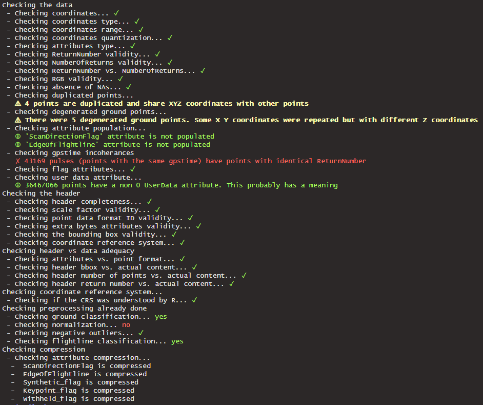

### Plotting

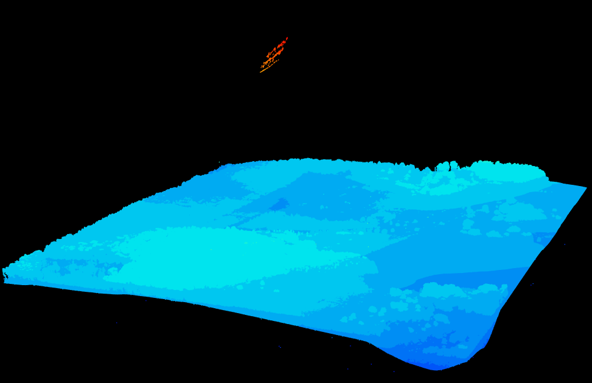

```r
plot(las)
```

```r
max(las@data[["Z"]])
```

```
## [1] 741.042
```

- höchste Erhebung im Göttinger Wald: Mackenröder Spitze (ca. 427 m ü. NHN)
- Riesenmammutbäume im Göttinger Wald???

#### Filterung der Punktwolke

- nur Punkte kleiner gleich 500 m –> also könnten immer noch ca. 70 m hohe Bäume enthalten sein

```r
las_new <- lidR::filter_poi(las, Z <= 500)
```

```r
plot(las_new)
```

[interactive chart not shown]

#### Cross section plot

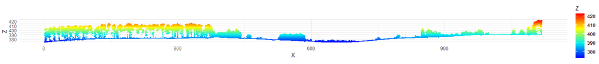

```r
p1 <- c(569250, 5708000)
p2 <- c(569750, 5709000 )
las_tr <- lidR::clip_transect(las_new, p1, p2, width = 4, xz = TRUE)

ggplot(las_tr@data, aes(X,Z, color = Z)) +
  geom_point(size = 0.5) +
  coord_equal() +
  theme_minimal() +
  scale_color_gradientn(colours = height.colors(50))
```

### Generierung eines Vegetationshöhenmodells

- stellt die Höhe der Vegetation dar
- für forstliche Untersuchungen besonders relevant

#### Höhen Normalisierung

- Beseitigung der Geländehöhe von der Gesamthöhe
- zwei Ansätze:

**1. Subtrahieren der DTM-Höhe von der DOM-Höhe**

$VHM = DOM - DGM$

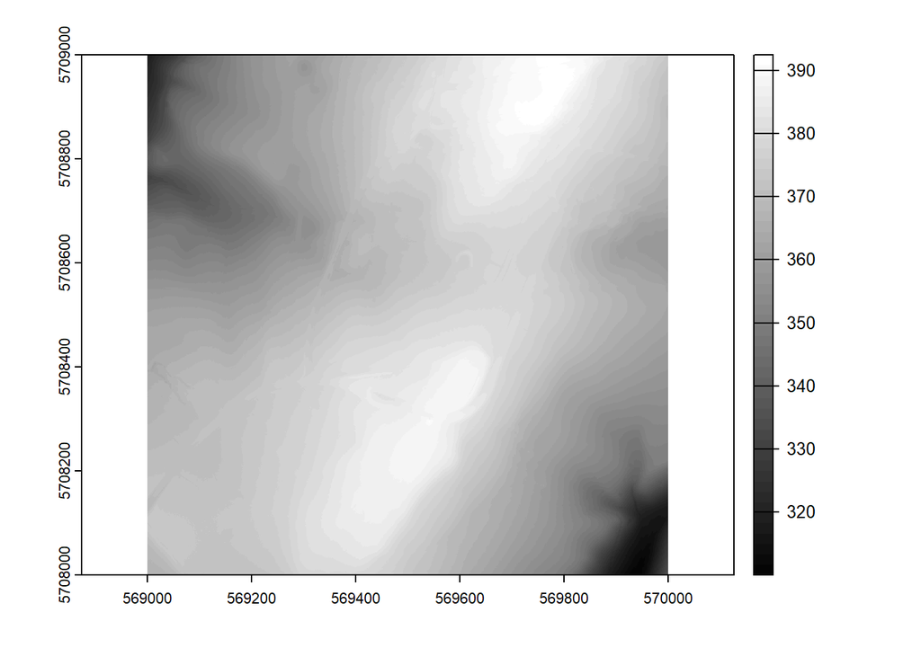

```r
dtm <- lidR::rasterize_terrain(las_new, res = 1, knnidw())
plot(dtm, col = gray(1:50/50))
```

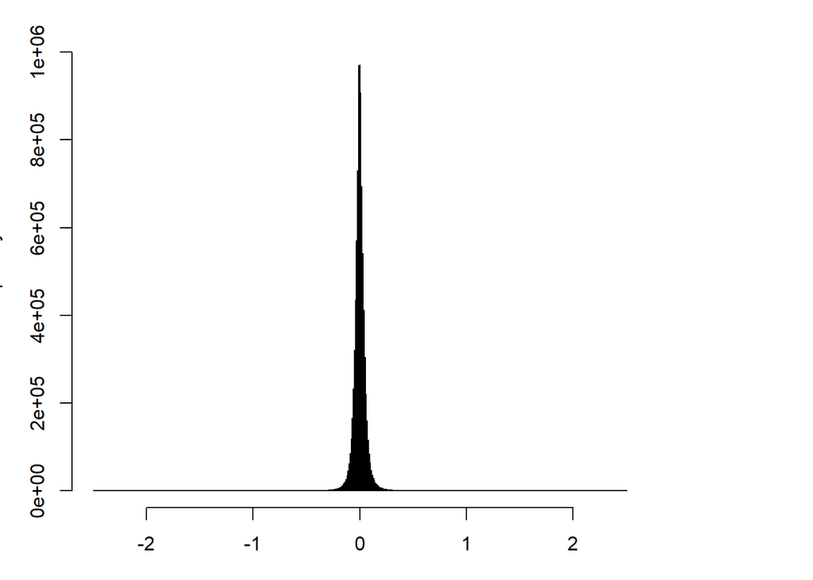

```r
nlas <- las_new - dtm

hist(filter_ground(nlas)$Z, breaks = seq(-2.5, 2.5, 0.01), main = "", xlab = "Höhe")
```

- nicht alle Bodenpunkte haben den Wert 0
- Grund: Rasterformat des DGM –> Lage der Pixel stimmt nicht mit der Lage der Bodenpunkte überein
- zu jedem Pixel mit einem Wert gibt es eigentlich mehrere Bodenpunkte
- alle Punkte innerhalb eines bestimmten Pixels werden mit dem exakt gleichen Höhenwert normalisiert

**2. Interpolation der Bodenpunkte und anschließend Subtraktion von den Nicht-Bodenpunkten**

- Interpolation der Höhe jedes einzelnen Punktes anhand von Bodenpunkten

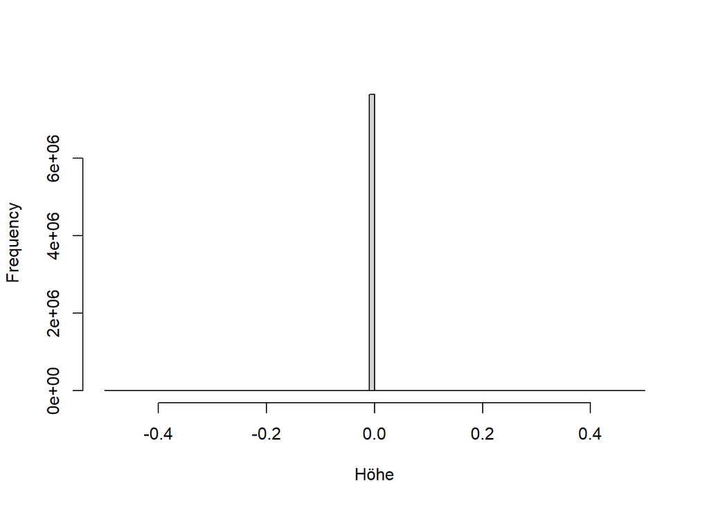

```r
nlas <- lidR::normalize_height(las_new, knnidw())

hist(filter_ground(nlas)$Z, breaks = seq(-0.5, 0.5, 0.01), main = "", xlab = "Höhe")
```

### Quellen

Roussel J, Goodbody TR, Tompalski P (2022). The lidR package. https://r-lidar.github.io/lidRbook/index.html

Roussel J, Auty D, Coops NC, Tompalski P, Goodbody TR, Meador AS, Bourdon J, de Boissieu F, Achim A (2020). “lidR: An R package for analysis of Airborne Laser Scanning (ALS) data.” Remote Sensing of Environment, 251, 112061. ISSN 0034-4257, doi:10.1016/j.rse.2020.112061, https://www.sciencedirect.com/science/article/pii/S0034425720304314.